# QTM 151 - Practice Quiz

**Submit as an HTML file** (see images below)

Step 1: Click the 3 dots in the toolbar for "More Actions"

[figure not shown]

Step 2: Choose "export"

[figure not shown]

Step 3: Select "HTML" from the dropdown window

[figure not shown]

Step 4: Select "Export" in the pop-up window.

[figure not shown]

Upload the .html file as your submission

Print your name below

```python
# Write your answer here

print("cynthia")
```

```
cynthia
```

This quiz is open book

- You can use the lecture notes
- You will get partial credit for attempting the questions
- To get full credit, the code should work as intended
- You should NOT communicate with other students

Print the following message:

"I will abide by Emory's code of conduct"

```python
# Write your answer here:
print()
```

Load in any necessary libraries/packages below:

```python
# load in necessary packages/libraries
import pandas as pd
import numpy as np
import matplotlib.pyplot as plt
```

Preliminary check: can you load the data?

In the .zip file you opened, there is a comma-separated values file named  
"HeightWeight-quiz.csv". Using Pandas, create a DataFrame object by reading in this file.

If you get an error, you must figure out what the issue is.

**Note**: This cell is just to test whether you can access the data correctly. If everything works, you can copy and paste the code later in the notebook if you prefer.

```python
# create a DataFrame by loading in the data
# You will need this for questions later.

dataframe = pd.read_csv('/Users/cynthia/Desktop/practice_quiz_2/data_folder/HeightWeight-quiz.csv')
```

(a) Making changes to a for loop

How would you change the code below, so that it prints out the position in the list of each non-numerical item it encounters?

Implement those changes, and run the code cell

```python
### Make changes to the code below

list_mixed = [1, 2, None, None, 4, 11, "Apple", 2.2, 13, "!!!", None]

list_sum = 0
index = 0

for value in list_mixed:
    index = index + 1
    if (type(value) != int) and (type(value) != float):
        print("Warning: Non-numerical element in list!")
        print(index)
        continue

    list_sum = list_sum + value

print(list_sum)
```

[output not shown]

(b) Debugging code

Below is a code which attempts to compute the sum $$1 + 2 + 3 + \cdots + (n-1) + n$$ for a positive integer $n$. For this example, we set $n = 10$. In this case, we would expect the output to be: $$ 1 + 2 + 3 + \cdots + 9 + 10 = \frac{10\times 11}{2} = 55$$

but that is not what is printed out when we run the cell below. Find the error in the code, and fix it. Then re-run the cell with $n = 19$, which should print the number $$ \frac{19\times 20}{2} = 190$$

```python
# Find the error and fix it.
# Then run the cell after setting n = 19
n = 19

sum_n = 0
for summands in range(1, n+1):
    sum_n = sum_n + summands

print(sum_n)

sum_n_wrong = 0
for summands1 in range(n+1):   #把n变成了n+1
    sum_n_wrong = sum_n_wrong + summands1

print(sum_n_wrong)

def func(n):
    numer = n * (n+1)
    denom = 2
    return numer / denom

aa = func(19)
print(aa)
```

```
190
190
190.0
```

c) Extracting and sorting subsets of data

In the .zip file you opened, there is a comma-separated values file named  
"HeightWeight-quiz.csv". Using Pandas, create a DataFrame object by reading in this file.

Extract rows 345 through 397 (that is, all the rows 345, 346, 347, ..., 396, 397) of the DataFrame, saving it as another DataFrame. Then sort this subset by Height (lowest to highest), assigning it to a DataFrame called `subset_sorted`

```python
# Write your answer here:

rowswanted = dataframe.iloc[345:398, :]
subset_sorted = rowswanted.sort_values(by = "Height_Inches")
print(subset_sorted)
```

```
     Index  Height_Inches  Weight_Pounds
394    395       63.76881       119.3691
359    360       64.18633       118.4759
377    378       64.66007       108.6044
369    370       65.72927       131.8008
378    379       65.73721       100.6617
384    385       66.04157       127.8822
360    361       66.09074       129.5516
392    393       66.44873       118.9856
387    388       66.46042       124.5581
346    347       66.46536       121.5515
396    397       66.48966       126.6122
370    371       66.49627       122.8561
397    398       66.74224       113.5597
353    354       67.13983       131.5906
```

[output cut: 39 more lines]

(d) Filtering a data set

Create two DataFrames containing the following subsets of the data:

- People who weight satisfies $115 \leq \textrm{weight} \leq 140$ (in pounds)
- People who either i) weigh strictly less than 95 pounds **or** ii) are 72 inches or taller (greater than or equal to 72 inches)

```python
# Write your answer here:

weight_sorted = rowswanted.sort_values(by = "Weight_Pounds")

#print(weight_sorted)
#weightok = weight_sorted.iloc[6:45, :]
#i want to get weights between 115 and 140
weightok = weight_sorted[(weight_sorted["Weight_Pounds"] >= 115) & (weight_sorted["Weight_Pounds"] <= 140)]
print(weightok)


q2 = dataframe[(dataframe["Weight_Pounds"] < 95) | (dataframe["Height_Inches"] >= 72)]
print(q2)
```

```
     Index  Height_Inches  Weight_Pounds
352    353       68.00435       115.6709
379    380       68.42441       116.1397
386    387       68.87697       116.3375
359    360       64.18633       118.4759
391    392       67.46867       118.7434
392    393       66.44873       118.9856
394    395       63.76881       119.3691
356    357       69.32618       119.9885
362    363       69.66512       120.8646
346    347       66.46536       121.5515
376    377       67.71342       122.6200
370    371       66.49627       122.8561
385    386       69.22880       123.1361
387    388       66.46042       124.5581
```

[output cut: 40 more lines]

(e) Random Assignment

We want to divide the dataset into 3 groups randomly: group A, group B, group C

Randomly assign each person in the dataset one of three possible strings: `"A"`, `"B"`, or `"C"`. Add a column/variable to the DataFrame which contains the letter each person is assigned. Give the column/variable the name `"Group"`

**Hint**: Randomly choosing among 3 strings is not much different from randomly choosing among 4 numbers, which is what we did in Lecture 11

```python
nn = len(dataframe)

group = np.random.choice(['a','b','c'], size=nn)

dataframe["Group"] = group

print(dataframe)
```

```
       Index  Height_Inches  Weight_Pounds Group
0          1       65.78331       112.9925     b
1          2       71.51521       136.4873     b
2          3       69.39874       153.0269     a
3          4       68.21660       142.3354     c
4          5       67.78781       144.2971     b
...      ...            ...            ...   ...
24995  24996       69.50215       118.0312     b
24996  24997       64.54826       120.1932     c
24997  24998       64.69855       118.2655     a
24998  24999       67.52918       132.2682     a
24999  25000       68.87761       124.8742     b

[25000 rows x 4 columns]
```

```python
# Write your answer here:
#完全不对
letter_assigned = []

for letter_assigned in dataframe:
    letter_assigned = np.random.choice(['a','b','c'])

dataframe["Group"] = letter_assigned

dataframe.iloc[:, :]
```

|  | Index | Height_Inches | Weight_Pounds | Group |
| --- | --- | --- | --- | --- |
| 0 | 1 | 65.78331 | 112.9925 | c |
| 1 | 2 | 71.51521 | 136.4873 | c |
| 2 | 3 | 69.39874 | 153.0269 | c |
| 3 | 4 | 68.21660 | 142.3354 | c |
| 4 | 5 | 67.78781 | 144.2971 | c |
| ... | ... | ... | ... | ... |
| 24995 | 24996 | 69.50215 | 118.0312 | c |
| 24996 | 24997 | 64.54826 | 120.1932 | c |
| 24997 | 24998 | 64.69855 | 118.2655 | c |
| 24998 | 24999 | 67.52918 | 132.2682 | c |
| 24999 | 25000 | 68.87761 | 124.8742 | c |

25000 rows × 4 columns

(f) Plotting data from one the groups

Give appropriate labels to the axes and give your scatter plot a reasonable title.

[output not shown]

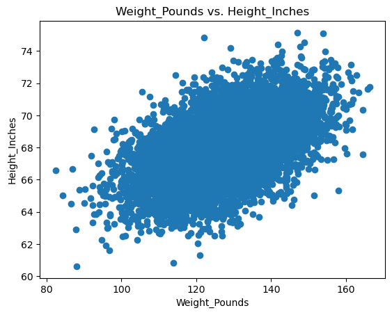

```python
# Write your answer here:

groupb = dataframe[dataframe["Group"] == "b"]
print(groupb)

plt.scatter(groupb["Weight_Pounds"], groupb["Height_Inches"])
plt.xlabel("Weight_Pounds")
plt.ylabel("Height_Inches")
plt.title("Weight_Pounds vs. Height_Inches")
plt.show()
```

(g) Convert your notebook to .html

Convert your notebook to .html format. You will be expected to submit your quiz in this format, so now is the time to make sure you can do it. Instructions are at the top of this notebook.

**A small point deduction will be taken off for submissions in the wrong format**